# Assignment 2: Spatial Analysis and Visualization

Healthcare Access and Equity in Pennsylvania

Author

Published

December 7, 2025

## Assignment Overview

**Learning Objectives:** - Apply spatial operations to answer policy-relevant research questions - Integrate census demographic data with spatial analysis - Create publication-quality visualizations and maps - Work with spatial data from multiple sources - Communicate findings effectively for policy audiences

## Part 1: Healthcare Access for Vulnerable Populations

### Research Question

**Which Pennsylvania counties have the highest proportion of vulnerable populations (elderly + low-income) living far from hospitals?**

Your analysis should identify counties that should be priorities for healthcare investment and policy intervention.

### Required Analysis Steps

Complete the following analysis, documenting each step with code and brief explanations:

#### Step 1: Data Collection (5 points)

Load the required spatial data: - Pennsylvania county boundaries - Pennsylvania hospitals (from lecture data) - Pennsylvania census tracts

**Your Task:**

```r
# Load required packages
library(sf)
library(tidyverse)
library(tigris)
library(tidycensus)
library(scales)
library(patchwork)
library(here)
library(knitr)
options(tigris_use_cache = TRUE, tigris_progress = FALSE)
# Load spatial data
pa_counties <- st_read(here("data/Pennsylvania_County_Boundaries.shp"))
hospitals <- st_read(here("data/hospitals.geojson"))
census_tracts <- tracts(state = "PA", cb = TRUE)

# Check that all data loaded correctly
head(pa_counties)
```

```
Simple feature collection with 6 features and 19 fields
Geometry type: MULTIPOLYGON
Dimension:     XY
Bounding box:  xmin: -8905670 ymin: 4862594 xmax: -8317930 ymax: 5161279
Projected CRS: WGS 84 / Pseudo-Mercator
  OBJECTID MSLINK COUNTY_NAM COUNTY_NUM FIPS_COUNT COUNTY_ARE COUNTY_PER
1      336     46 MONTGOMERY         46        091       <NA>       <NA>
2      337      8   BRADFORD         08        015       <NA>       <NA>
3      338      9      BUCKS         09        017       <NA>       <NA>
4      339     58      TIOGA         58        117       <NA>       <NA>
5      340     59      UNION         59        119       <NA>       <NA>
6      341     60    VENANGO         60        121       <NA>       <NA>
  NUMERIC_LA COUNTY_N_1 AREA_SQ_MI SOUND SPREAD_SHE IMAGE_NAME NOTE_FILE VIDEO
1          5         46   487.4271  <NA>       <NA>   poll.bmp      <NA>  <NA>
2          2          8  1161.3379  <NA>       <NA>   poll.bmp      <NA>  <NA>
3          5          9   622.0836  <NA>       <NA>   poll.bmp      <NA>  <NA>
4          2         58  1137.2480  <NA>       <NA>   poll.bmp      <NA>  <NA>
5          2         59   319.1893  <NA>       <NA>   poll.bmp      <NA>  <NA>
6          3         60   683.3676  <NA>       <NA>   poll.bmp      <NA>  <NA>
  DISTRICT_N PA_CTY_COD MAINT_CTY_ DISTRICT_O                       geometry
1         06         46          4        6-4 MULTIPOLYGON (((-8398884 48...
2         03         08          9        3-9 MULTIPOLYGON (((-8558633 51...
3         06         09          1        6-1 MULTIPOLYGON (((-8367360 49...
4         03         59          7        3-7 MULTIPOLYGON (((-8558633 51...
5         03         60          8        3-8 MULTIPOLYGON (((-8562865 49...
6         01         61          5        1-5 MULTIPOLYGON (((-8870781 50...
```

```r
head(hospitals)
```

```
Simple feature collection with 6 features and 11 fields
Geometry type: POINT
Dimension:     XY
Bounding box:  xmin: -80.27907 ymin: 39.80913 xmax: -75.17005 ymax: 40.24273
Geodetic CRS:  WGS 84
                 CHIEF_EXEC              CHIEF_EX_1
1             Peter J Adamo               President
2          Autumn DeShields Chief Executive Officer
3              Shawn Parekh Chief Executive Officer
4               DIANE HRITZ Chief Executive Officer
5            Tim Harclerode Chief Executive Officer
6 Richard McLaughlin MD MBA Chief Executive Officer
                      FACILITY_U LONGITUDE       COUNTY
1   https://www.phhealthcare.org -79.91131   Washington
2      https://www.malvernbh.com -75.17005 Philadelphia
```

[output cut: 18 more lines]

```r
head(census_tracts)
```

```
Simple feature collection with 6 features and 13 fields
Geometry type: MULTIPOLYGON
Dimension:     XY
Bounding box:  xmin: -78.42478 ymin: 39.79351 xmax: -75.93766 ymax: 40.54328
Geodetic CRS:  NAD83
  STATEFP COUNTYFP TRACTCE              GEOIDFQ       GEOID   NAME
1      42      001  031101 1400000US42001031101 42001031101 311.01
2      42      013  100400 1400000US42013100400 42013100400   1004
3      42      013  100500 1400000US42013100500 42013100500   1005
4      42      013  100800 1400000US42013100800 42013100800   1008
5      42      013  101900 1400000US42013101900 42013101900   1019
6      42      011  011200 1400000US42011011200 42011011200    112
             NAMELSAD STUSPS   NAMELSADCO   STATE_NAME LSAD   ALAND AWATER
1 Census Tract 311.01     PA Adams County Pennsylvania   CT 3043185      0
2   Census Tract 1004     PA Blair County Pennsylvania   CT  993724      0
3   Census Tract 1005     PA Blair County Pennsylvania   CT 1130204      0
4   Census Tract 1008     PA Blair County Pennsylvania   CT  996553      0
5   Census Tract 1019     PA Blair County Pennsylvania   CT  573726      0
6    Census Tract 112     PA Berks County Pennsylvania   CT 1539365   9308
                        geometry
1 MULTIPOLYGON (((-77.03108 3...
2 MULTIPOLYGON (((-78.42478 4...
3 MULTIPOLYGON (((-78.41661 4...
4 MULTIPOLYGON (((-78.41067 4...
5 MULTIPOLYGON (((-78.40836 4...
6 MULTIPOLYGON (((-75.95433 4...
```

**Questions to answer:** - How many hospitals are in your dataset?

233

- How many census tracts?

  3445
- What coordinate reference system is each dataset in?

#### Step 2: Get Demographic Data

Use `tidycensus` to download tract-level demographic data for Pennsylvania.

**Required variables:** - Total population - Median household income - Population 65 years and over (you may need to sum multiple age categories)

**Your Task:**

```r
# Get demographic data from ACS
df=load_variables(2023,"acs5/profile")
data=c(population="DP02_0018",age="DP05_0024",income="DP03_0062")
df = get_acs(state = "PA",
              variables = data,
              survey = "acs5",
             geometry = TRUE,
             geography = "tract",
             output = "wide",
             year = 2023)



# Join to tract boundaries
#I already downloaded my geography when using tidycensus
sum(is.na(df$incomeE))
```

```
[1] 66
```

```r
median(df$incomeE,na.rm = TRUE)
```

```
[1] 72943.5
```

**Questions to answer:** - What year of ACS data are you using?

2019-2023 5 year acs

- How many tracts have missing income data?

  66
- What is the median income across all PA census tracts?

  72943.5

#### Step 3: Define Vulnerable Populations

Identify census tracts with vulnerable populations based on TWO criteria: 1. Low median household income (choose an appropriate threshold) 2. Significant elderly population (choose an appropriate threshold)

**Your Task:**

```r
# Filter for vulnerable tracts based on your criteria

summary(df)
```

```
    GEOID               NAME            populationE     populationM
 Length:3446        Length:3446        Min.   :    0   Min.   :   7.0
 Class :character   Class :character   1st Qu.: 2506   1st Qu.: 246.2
 Mode  :character   Mode  :character   Median : 3522   Median : 375.0
                                       Mean   : 3646   Mean   : 402.4
                                       3rd Qu.: 4658   3rd Qu.: 527.0
                                       Max.   :10388   Max.   :2092.0

      ageE             ageM          incomeE          incomeM
 Min.   :   0.0   Min.   :  3.0   Min.   : 13307   Min.   :   472
 1st Qu.: 429.0   1st Qu.: 94.0   1st Qu.: 57864   1st Qu.:  9324
 Median : 665.0   Median :138.0   Median : 72944   Median : 13780
 Mean   : 718.6   Mean   :156.2   Mean   : 80731   Mean   : 16219
 3rd Qu.: 945.0   3rd Qu.:199.0   3rd Qu.: 96691   3rd Qu.: 20141
 Max.   :2541.0   Max.   :826.0   Max.   :250001   Max.   :208341
                                  NA's   :66       NA's   :74
          geometry
 MULTIPOLYGON :3446
 epsg:4269    :   0
 +proj=long...:   0
```

```r
vulnerable=df%>%
  filter(ageE>945|incomeE<32150)

print(vulnerable)
```

```
Simple feature collection with 974 features and 8 fields
Geometry type: MULTIPOLYGON
Dimension:     XY
Bounding box:  xmin: -80.51989 ymin: 39.7198 xmax: -74.77683 ymax: 42.18103
Geodetic CRS:  NAD83
First 10 features:
         GEOID                                             NAME populationE
1  42001031101  Census Tract 311.01; Adams County; Pennsylvania        4865
2  42011000100       Census Tract 1; Berks County; Pennsylvania        4357
3  42011013302  Census Tract 133.02; Berks County; Pennsylvania        6438
4  42015950300 Census Tract 9503; Bradford County; Pennsylvania        5389
5  42017101607 Census Tract 1016.07; Bucks County; Pennsylvania        4564
6  42017101403 Census Tract 1014.03; Bucks County; Pennsylvania        6207
7  42017104901 Census Tract 1049.01; Bucks County; Pennsylvania        6762
8  42025020700    Census Tract 207; Carbon County; Pennsylvania        5256
9  42027011800    Census Tract 118; Centre County; Pennsylvania        5904
10 42029304000  Census Tract 3040; Chester County; Pennsylvania        5363
   populationM ageE ageM incomeE incomeM                       geometry
1          412  995  261   64985   10752 MULTIPOLYGON (((-77.03108 3...
2          642  684  235   24613    6851 MULTIPOLYGON (((-75.93179 4...
3          279 2017  414   96063    8531 MULTIPOLYGON (((-75.65603 4...
4           20 1056  186   55393   15400 MULTIPOLYGON (((-76.53679 4...
5          604 1602  430   93580   26482 MULTIPOLYGON (((-75.08177 4...
6          593 1365  311  105927   36551 MULTIPOLYGON (((-74.98383 4...
7          747 1067  172  173708    6918 MULTIPOLYGON (((-75.11312 4...
8          225  951  223   81875   11766 MULTIPOLYGON (((-75.71378 4...
9           19 1178  223  107769   16251 MULTIPOLYGON (((-77.83571 4...
10          25  952  204   97772    7400 MULTIPOLYGON (((-75.70888 3...
```

```r
974/3446
```

```
[1] 0.2826465
```

**Questions to answer:**

- What income threshold did you choose and why?

  I chose $32,150, which is the penn poverty line
- What elderly population threshold did you choose and why?

  I chose the 3rd quantile
- How many tracts meet your vulnerability criteria?

  974
- What percentage of PA census tracts are considered vulnerable by your definition?

  28%

#### Step 4: Calculate Distance to Hospitals

For each vulnerable tract, calculate the distance to the nearest hospital.

**Your Task:**

```r
# Transform to appropriate projected CRS
vulnerable_proj=vulnerable%>%
  st_transform(3365)

host_proj=hospitals%>%
  st_transform(3365)

# Calculate distance from each tract centroid to nearest hospital
vulnerable_center=st_centroid(vulnerable_proj)

dist <- vulnerable_center %>%
  mutate(
    dis_to_tract = apply(
      st_distance(st_centroid(vulnerable_center), host_proj),
      1,
      min
    ) *0.000189
  )

mean(dist$dis_to_tract)
```

```
[1] 4.173085
```

```r
max(dist$dis_to_tract)
```

```
[1] 25.90749
```

```r
dist$indi=ifelse(dist$dis_to_tract>15,1,0)
summary(dist$indi==1)
```

```
   Mode   FALSE    TRUE
logical     957      17
```

**Requirements:** - Use an appropriate projected coordinate system for Pennsylvania - Calculate distances in miles - Explain why you chose your projection

**Questions to answer:** - What is the average distance to the nearest hospital for vulnerable tracts?

4.17

- What is the maximum distance?

  25.91
- How many vulnerable tracts are more than 15 miles from the nearest hospital?

  17

#### Step 5: Identify Underserved Areas

Define “underserved” as vulnerable tracts that are more than 15 miles from the nearest hospital.

**Your Task:**

```r
# Create underserved variable
underserved=dist%>%
  filter(indi==1)
17/973
```

```
[1] 0.01747174
```

**Questions to answer:** - How many tracts are underserved?

17

- What percentage of vulnerable tracts are underserved?

  1.7%
- Does this surprise you? Why or why not?

  Yes, as 15 miles is such a long way and there are still 17 tracts that are so far away, it should be less than 10

#### Step 6: Aggregate to County Level

Use spatial joins and aggregation to calculate county-level statistics about vulnerable populations and hospital access.

**Your Task:**

```r
# Spatial join tracts to counties
df = get_acs(state = "PA",
              variables = data,
              survey = "acs5",
             geometry = TRUE,
             geography = "county",
             output = "wide")

# Aggregate statistics by county

dist_final=dist%>%
  st_drop_geometry()%>%
  mutate(NAME=str_remove(NAME,"; Pennsylvania"))

dist_final[,11:12] = str_split_fixed(dist_final$NAME,";",2)

df_removed=df%>%
  mutate(NAME=str_remove(NAME,", Pennsylvania"))%>%
  mutate(NAME = str_trim(str_to_title(NAME)))

dist_final2=dist_final%>%
  mutate(NAME=V12)%>%
  mutate(NAME = str_trim(str_to_title(NAME)))%>%
  group_by(NAME)%>%
  summarise(
    vulnerable=n(),
    underserved=sum(indi==1),
    per=underserved/vulnerable,
    avg_dis=mean(dis_to_tract),
    vulner_pop=sum(populationE)
  )

df_removed=df_removed%>%
  left_join(dist_final2,by="NAME")
```

**Required county-level statistics:** - Number of vulnerable tracts - Number of underserved tracts  
- Percentage of vulnerable tracts that are underserved - Average distance to nearest hospital for vulnerable tracts - Total vulnerable population

**Questions to answer:** - Which 5 counties have the highest percentage of underserved vulnerable tracts?

Pike, Wyoming, Bradford, Clearfield, and Snyder

#### Step 7: Create Summary Table

Create a professional table showing the top 10 priority counties for healthcare investment.

**Your Task:**

```r
library(scales)
# Create and format priority counties table
df_table=df_removed%>%
  st_drop_geometry()%>%
  mutate(percentage=round(per*100,digits = 3))%>%
  mutate(pop=comma(populationE))%>%
  mutate(distance=round(avg_dis,digits = 3))%>%
  select(NAME,pop,vulnerable,underserved, percentage, distance, vulner_pop)

final_table=df_table[order(df_table$percentage,decreasing=TRUE),]




kable(final_table, col.names=c("County Name","Population","Number of Vulnerable Tracts","Underserved Tracts",
                            "Percentage of Underserved Tract","Average Distance to Nearest Hospital",
                            "Vulnerable Population"),format = "html",row.names = FALSE,
      bootstrap_options=c("striped", "hover", "condensed"),
    full_width = FALSE,
    position = "center",caption = "County-level summary of population, vulnerable tracts, underserved tracts, and hospital accessibility in Pennsylvania.")
```

County-level summary of population, vulnerable tracts, underserved tracts, and hospital accessibility in Pennsylvania.

| County Name | Population | Number of Vulnerable Tracts | Underserved Tracts | Percentage of Underserved Tract | Average Distance to Nearest Hospital | Vulnerable Population |
| --- | --- | --- | --- | --- | --- | --- |
| Pike County | 59,299 | 2 | 2 | 100.000 | 23.530 | 8286 |
| Wyoming County | 25,361 | 1 | 1 | 100.000 | 19.341 | 4185 |
| Snyder County | 36,745 | 5 | 2 | 40.000 | 13.474 | 27456 |
| Bradford County | 59,250 | 5 | 2 | 40.000 | 12.210 | 23832 |
| Clearfield County | 74,316 | 7 | 2 | 28.571 | 11.134 | 34432 |
| Huntingdon County | 38,896 | 4 | 1 | 25.000 | 7.981 | 18514 |
| Northumberland County | 87,265 | 5 | 1 | 20.000 | 10.794 | 27608 |
| Crawford County | 79,317 | 8 | 1 | 12.500 | 6.455 | 36036 |
| Chester County | 525,607 | 30 | 2 | 6.667 | 5.273 | 165947 |
| Cumberland County | 251,371 | 25 | 1 | 4.000 | 6.531 | 144521 |
| Dauphin County | 280,910 | 25 | 1 | 4.000 | 4.464 | 136085 |
| York County | 451,220 | 36 | 1 | 2.778 | 5.379 | 179014 |
| Somerset County | 68,975 | 6 | 0 | 0.000 | 3.504 | 22463 |
| Centre County | 137,615 | 9 | 0 | 0.000 | 4.223 | 38866 |
| Clinton County | 36,080 | 4 | 0 | 0.000 | 8.046 | 15682 |
| Allegheny County | 1,204,750 | 108 | 0 | 0.000 | 2.574 | 482906 |
| Westmoreland County | 345,888 | 36 | 0 | 0.000 | 4.661 | 146373 |
| Franklin County | 154,791 | 12 | 0 | 0.000 | 3.948 | 65501 |
| Bucks County | 636,706 | 50 | 0 | 0.000 | 3.748 | 280864 |
| Warren County | 37,525 | 1 | 0 | 0.000 | 8.382 | 5066 |
| Montgomery County | 838,834 | 54 | 0 | 0.000 | 2.205 | 279603 |
| Erie County | 256,390 | 32 | 0 | 0.000 | 3.739 | 135226 |
| Washington County | 204,089 | 15 | 0 | 0.000 | 3.934 | 76139 |
| Delaware County | 553,942 | 29 | 0 | 0.000 | 2.987 | 144998 |
| Wayne County | 47,948 | 4 | 0 | 0.000 | 5.051 | 17029 |
| Northampton County | 303,453 | 26 | 0 | 0.000 | 4.422 | 134840 |
| Monroe County | 164,984 | 8 | 0 | 0.000 | 7.279 | 40647 |
| Clarion County | 35,766 | 1 | 0 | 0.000 | 7.073 | 4525 |
| Armstrong County | 64,293 | 4 | 0 | 0.000 | 6.358 | 20540 |
| Juniata County | 23,140 | 1 | 0 | 0.000 | 8.809 | 5560 |
| Lancaster County | 540,847 | 50 | 0 | 0.000 | 4.511 | 274969 |
| Perry County | 45,501 | 5 | 0 | 0.000 | 8.840 | 25008 |
| Greene County | 32,107 | 1 | 0 | 0.000 | 9.286 | 5359 |
| Philadelphia County | 1,534,829 | 103 | 0 | 0.000 | 1.122 | 471644 |
| Fayette County | 122,435 | 12 | 0 | 0.000 | 5.952 | 52205 |
| Indiana County | 77,912 | 5 | 0 | 0.000 | 3.164 | 19998 |
| Schuylkill County | 136,306 | 10 | 0 | 0.000 | 5.955 | 47762 |
| Jefferson County | 43,360 | 3 | 0 | 0.000 | 3.682 | 14537 |
| Columbia County | 61,190 | 4 | 0 | 0.000 | 8.047 | 21643 |
| Cambria County | 125,751 | 13 | 0 | 0.000 | 5.220 | 52575 |
| Elk County | 30,357 | 3 | 0 | 0.000 | 5.468 | 15249 |
| Venango County | 48,968 | 3 | 0 | 0.000 | 8.728 | 12686 |
| Mercer County | 103,241 | 10 | 0 | 0.000 | 4.375 | 43331 |
| Tioga County | 40,144 | 4 | 0 | 0.000 | 8.561 | 17895 |
| Susquehanna County | 38,026 | 3 | 0 | 0.000 | 7.602 | 12544 |
| Fulton County | 14,482 | 3 | 0 | 0.000 | 7.194 | 14482 |
| Mckean County | 37,353 | 1 | 0 | 0.000 | 14.160 | 5054 |
| Beaver County | 164,101 | 9 | 0 | 0.000 | 4.842 | 43615 |
| Lawrence County | 83,246 | 8 | 0 | 0.000 | 3.467 | 26832 |
| Lehigh County | 366,088 | 27 | 0 | 0.000 | 3.115 | 152497 |
| Blair County | 118,005 | 9 | 0 | 0.000 | 2.836 | 38284 |
| Lackawanna County | 207,584 | 16 | 0 | 0.000 | 4.051 | 83582 |
| Montour County | 17,268 | 3 | 0 | 0.000 | 1.141 | 13466 |
| Butler County | 190,460 | 18 | 0 | 0.000 | 6.679 | 91244 |
| Adams County | 100,831 | 8 | 0 | 0.000 | 5.852 | 42363 |
| Bedford County | 47,034 | 5 | 0 | 0.000 | 7.495 | 22509 |
| Carbon County | 64,316 | 7 | 0 | 0.000 | 4.200 | 33720 |
| Berks County | 416,342 | 25 | 0 | 0.000 | 3.727 | 127998 |
| Mifflin County | 45,377 | 5 | 0 | 0.000 | 5.964 | 21391 |
| Lebanon County | 139,845 | 15 | 0 | 0.000 | 4.196 | 80692 |
| Union County | 33,756 | 3 | 0 | 0.000 | 4.830 | 17096 |
| Lycoming County | 107,717 | 9 | 0 | 0.000 | 3.111 | 48483 |
| Luzerne County | 315,008 | 20 | 0 | 0.000 | 4.226 | 94118 |
| Potter County | 16,025 | 1 | 0 | 0.000 | 0.662 | 4031 |
| Sullivan County | 5,510 | NA | NA | NA | NA | NA |
| Cameron County | 4,420 | NA | NA | NA | NA | NA |
| Forest County | 4,399 | NA | NA | NA | NA | NA |

**Requirements:** - Use `knitr::kable()` or similar for formatting - Include descriptive column names - Format numbers appropriately (commas for population, percentages, etc.) - Add an informative caption - Sort by priority (you decide the metric)

## Part 2: Comprehensive Visualization

Using the skills from Week 3 (Data Visualization), create publication-quality maps and charts.

### Map 1: County-Level Choropleth

Create a choropleth map showing healthcare access challenges at the county level.

**Your Task:**

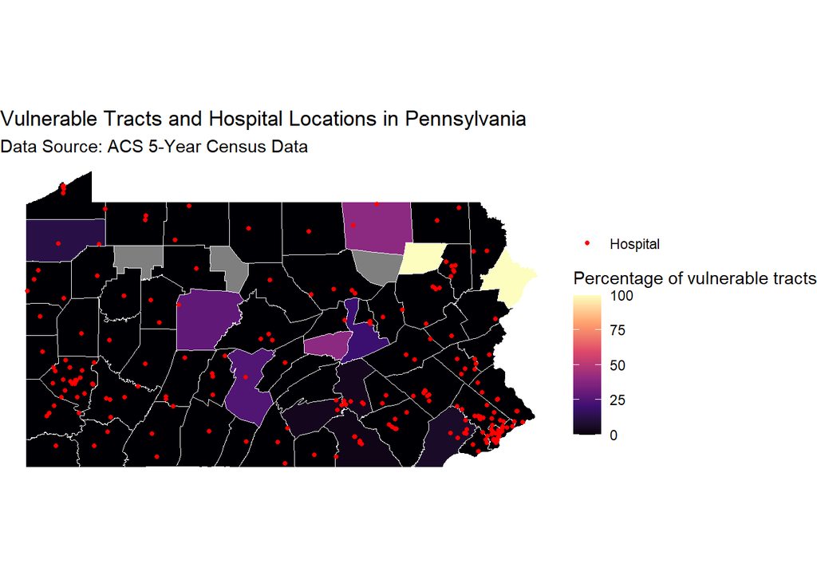

```r
# Create county-level access map
df_removed$percentage=df_removed$per*100
ggplot(df_removed) +
  geom_sf(aes(fill = percentage), color = "white")+
  geom_sf(data = host_proj, aes(color = "Hospital"),size=1)+
  scale_fill_viridis_c(
    name = "Percentage of vulnerable tracts",
    option = "magma"
  ) +
  scale_color_manual(
    name="",
    values = c("Hospital" = "red")
  )+
  labs(
    title = "Vulnerable Tracts and Hospital Locations in Pennsylvania",
    subtitle="Data Source: ACS 5-Year Census Data"
  ) +
  theme_void()
```

**Requirements:** - Fill counties by percentage of vulnerable tracts that are underserved - Include hospital locations as points - Use an appropriate color scheme - Include clear title, subtitle, and caption - Use `theme_void()` or similar clean theme - Add a legend with formatted labels

### Map 2: Detailed Vulnerability Map

Create a map highlighting underserved vulnerable tracts.

**Your Task:**

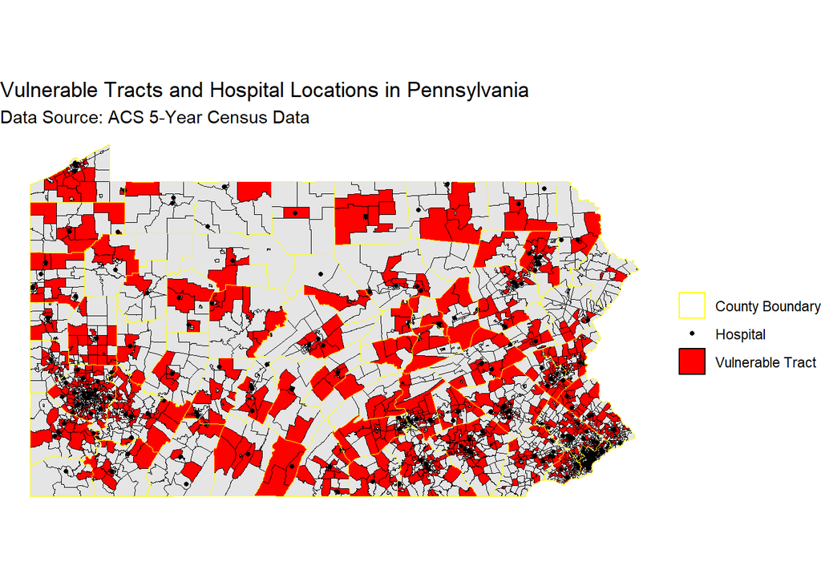

```r
# Create detailed tract-level map
dist_final_map=dist_final%>%
  group_by(GEOID)%>%
  summarise(
    vulnerable=n(),
    underserved=sum(indi==1),
    per=underserved/vulnerable,
    avg_dis=mean(dis_to_tract),
    vulner_pop=sum(populationE)
  )

dist_final_map2=vulnerable_proj%>%
  left_join(dist_final_map,by="GEOID")

ggplot() +
  geom_sf(data = census_tracts, color="black")+
  geom_sf(data=dist_final_map2,fill="red",aes(color="Vulnerable Tract"))+
  geom_sf(data = host_proj, aes(color = "Hospital"),size=1)+
  geom_sf(data = df_removed,fill= NA,aes(color = "County Boundary"),size=6, alpha= 1)+
  scale_fill_viridis_c(
    name = "Percentage of vulnerable tracts",
    option = "magma"
  ) +
  scale_color_manual(
    name="",
    values = c("Hospital" = "black","Vulnerable Tract"="black","County Boundary"="yellow")
  )+
  labs(
    title = "Vulnerable Tracts and Hospital Locations in Pennsylvania",
    subtitle = "Data Source: ACS 5-Year Census Data"
  ) +
  theme_void()
```

**Requirements:** - Show underserved vulnerable tracts in a contrasting color - Include county boundaries for context - Show hospital locations - Use appropriate visual hierarchy (what should stand out?) - Include informative title and subtitle